# Used Keras to visualize inputs of VGG16

It includes 4 tasks. The specific steps for this task are:

1. Create input images that maximize the activation of specific filters in a target layer. Such images represent a visualization of the pattern that the filter responds to.
2. Visualize the first 8 filters in the following layers: conv1_1, conv2_1, conv3_1,conv4_1, and conv5_1.
3. To notice the features in the different filters.
4. To know What kind of information does each filter learn.

```python
import numpy as np
import tensorflow as tf
from tensorflow import keras
from IPython.display import Image, display
import matplotlib.pyplot as plt
```

[output not shown]

Build a VGG16 model

VGG16 is a convolution neural net (CNN ) architecture which was used to win ILSVR(Imagenet) competition in 2014.

The VGG16 architecture consists of 13 convolutional layers and 3 fully connected layers.

The layers in VGG16 would be named as follows:

```
Convolutional layers:
    Conv1_1
    Conv1_2
    MaxPool1
    Conv2_1
    Conv2_2
    MaxPool2
    Conv3_1
    Conv3_2
    Conv3_3
    MaxPool3
    Conv4_1
    Conv4_2
    Conv4_3
    MaxPool4
    Conv5_1
    Conv5_2
    Conv5_3
    MaxPool5

Fully connected layers:
    Platten
    FC1
    FC2
    Predictions (output layer)
```

```python
# The dimensions of our input image
img_width = 180
img_height = 180

#create the VGG16 model
input_shape = (180,180,3)
model_VGG16 = keras.Sequential()
model_VGG16.add(keras.layers.Conv2D(input_shape=input_shape,filters=64,kernel_size=(3,3),padding="same",activation="relu",name='conv1_1'))
model_VGG16.add(keras.layers.Conv2D(filters=64,kernel_size=(3,3),padding='same',activation="relu",name='conv1_2'))
model_VGG16.add(keras.layers.MaxPool2D(pool_size=(2,2),strides=(2,2),name='conv1_pool'))

model_VGG16.add(keras.layers.Conv2D(filters=128,kernel_size=(3,3),padding='same',activation="relu",name='conv2_1'))
model_VGG16.add(keras.layers.Conv2D(filters=128,kernel_size=(3,3),padding='same',activation="relu",name='conv2_2'))
model_VGG16.add(keras.layers.MaxPool2D(pool_size=(2,2),strides=(2,2),name='conv2_pool'))

model_VGG16.add(keras.layers.Conv2D(filters=256,kernel_size=(3,3),padding='same',activation="relu",name='conv3_1'))
model_VGG16.add(keras.layers.Conv2D(filters=256,kernel_size=(3,3),padding='same',activation="relu",name='conv3_2'))
model_VGG16.add(keras.layers.Conv2D(filters=256,kernel_size=(3,3),padding='same',activation="relu",name='conv3_3'))
model_VGG16.add(keras.layers.MaxPool2D(pool_size=(2,2),strides=(2,2),name='conv3_pool'))

model_VGG16.add(keras.layers.Conv2D(filters=512,kernel_size=(3,3),padding='same',activation="relu",name='conv4_1'))
model_VGG16.add(keras.layers.Conv2D(filters=512,kernel_size=(3,3),padding='same',activation="relu",name='conv4_2'))
model_VGG16.add(keras.layers.Conv2D(filters=512,kernel_size=(3,3),padding='same',activation="relu",name='conv4_3'))
model_VGG16.add(keras.layers.MaxPool2D(pool_size=(2,2),strides=(2,2),name='conv4_pool'))

model_VGG16.add(keras.layers.Conv2D(filters=512,kernel_size=(3,3),padding='same',activation="relu",name='conv5_1'))
model_VGG16.add(keras.layers.Conv2D(filters=512,kernel_size=(3,3),padding='same',activation="relu",name='conv5_2'))
model_VGG16.add(keras.layers.Conv2D(filters=512,kernel_size=(3,3),padding='same',activation="relu",name='conv5_3'))
model_VGG16.add(keras.layers.MaxPool2D(pool_size=(2,2),strides=(2,2)))

#add the fully connected layers
model_VGG16.add(keras.layers.Flatten(name='flatten'))
model_VGG16.add(keras.layers.Dense(units=4096,activation="relu",name='fc1'))
model_VGG16.add(keras.layers.Dense(units=4096,activation="relu",name='fc2'))
model_VGG16.add(keras.layers.Dense(units=1000,activation="softmax",name='predictions'))

#print the model summary
model_VGG16.summary()
```

[output not shown]

```
Model: "sequential"
_________________________________________________________________
 Layer (type)                Output Shape              Param #
=================================================================
 conv1_1 (Conv2D)            (None, 180, 180, 64)      1792

 conv1_2 (Conv2D)            (None, 180, 180, 64)      36928

 conv1_pool (MaxPooling2D)   (None, 90, 90, 64)        0

 conv2_1 (Conv2D)            (None, 90, 90, 128)       73856

 conv2_2 (Conv2D)            (None, 90, 90, 128)       147584

 conv2_pool (MaxPooling2D)   (None, 45, 45, 128)       0

 conv3_1 (Conv2D)            (None, 45, 45, 256)       295168

 conv3_2 (Conv2D)            (None, 45, 45, 256)       590080

 conv3_3 (Conv2D)            (None, 45, 45, 256)       590080

 conv3_pool (MaxPooling2D)   (None, 22, 22, 256)       0

 conv4_1 (Conv2D)            (None, 22, 22, 512)       1180160

 conv4_2 (Conv2D)            (None, 22, 22, 512)       2359808

 conv4_3 (Conv2D)            (None, 22, 22, 512)       2359808

 conv4_pool (MaxPooling2D)   (None, 11, 11, 512)       0

 conv5_1 (Conv2D)            (None, 11, 11, 512)       2359808

 conv5_2 (Conv2D)            (None, 11, 11, 512)       2359808

 conv5_3 (Conv2D)            (None, 11, 11, 512)       2359808

 max_pooling2d (MaxPooling2D  (None, 5, 5, 512)        0
 )

 flatten (Flatten)           (None, 12800)             0

 fc1 (Dense)                 (None, 4096)              52432896

 fc2 (Dense)                 (None, 4096)              16781312

 predictions (Dense)         (None, 1000)              4097000

=================================================================
Total params: 88,025,896
Trainable params: 88,025,896
Non-trainable params: 0
_________________________________________________________________
```

Build a feature extraction model

```python
# Set up a model that returns the activation values for our target layer
layer_name='conv3_2'
layer = model_VGG16.get_layer(name=layer_name)
feature_extractor = keras.Model(inputs=model_VGG16.inputs, outputs=layer.output)
```

Set up the gradient ascent process

The "loss" we will maximize is simply the mean of the activation of a specific filter in our target layer. To avoid border effects, we exclude border pixels.

Our gradient ascent function simply computes the gradients of the loss above with regard to the input image, and update the update image so as to move it towards a state that will activate the target filter more strongly.

```python
def compute_loss(input_image, filter_index):
    activation = feature_extractor(input_image)
    # We avoid border artifacts by only involving non-border pixels in the loss.
    filter_activation = activation[:, 2:-2, 2:-2, filter_index]
    return tf.reduce_mean(filter_activation)


def gradient_ascent_step(img, filter_index, learning_rate):
    with tf.GradientTape() as tape:
        tape.watch(img)
        loss = compute_loss(img, filter_index)
    # Compute gradients.
    grads = tape.gradient(loss, img)
    # Normalize gradients.
    grads = tf.math.l2_normalize(grads)
    img += learning_rate * grads
    return loss, img
```

Set up the end-to-end filter visualization loop

Our process is as follow:

```
Start from a random image that is close to "all gray" (i.e. visually netural)
Repeatedly apply the gradient ascent step function defined above
Convert the resulting input image back to a displayable form, by normalizing it, center-cropping it, and restricting it to the [0, 255] range.
```

```python
def initialize_image():
    # We start from a gray image with some random noise
    img = tf.random.uniform((1, img_width, img_height, 3))
    # ResNet50V2 expects inputs in the range [-1, +1].
    # Here we scale our random inputs to [-0.125, +0.125]
    return (img - 0.5) * 0.25


def visualize_filter(filter_index):
    # We run gradient ascent for 20 steps
    iterations = 30
    learning_rate = 10.0
    img = initialize_image()
    for iteration in range(iterations):
        loss, img = gradient_ascent_step(img, filter_index, learning_rate)

    # Decode the resulting input image
    img = deprocess_image(img[0].numpy())
    return loss, img


def deprocess_image(img):
    # Normalize array: center on 0., ensure variance is 0.15
    img -= img.mean()
    img /= img.std() + 1e-5
    img *= 0.15

    # Center crop
    img = img[25:-25, 25:-25, :]

    # Clip to [0, 1]
    img += 0.5
    img = np.clip(img, 0, 1)

    # Convert to RGB array
    img *= 255
    img = np.clip(img, 0, 255).astype("uint8")
    return img
```

Task1: Create input images that maximize the activation of specific filters in a target layer. Such images represent a visualization of the pattern that the filter responds to.

Visualize the first 16 filters in the target layer. Making a 4x4 grid to get of feel for the range of different visual patterns that the model has learned.

```
Now is processing the target layer conv3_2
Processing filter 0
Processing filter 1
Processing filter 2
Processing filter 3
Processing filter 4
Processing filter 5
Processing filter 6
Processing filter 7
Processing filter 8
Processing filter 9
Processing filter 10
Processing filter 11
Processing filter 12
Processing filter 13
Processing filter 14
Processing filter 15
```

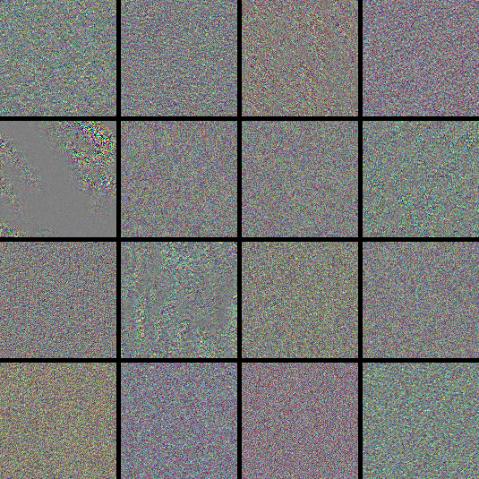

```python
# Compute image inputs that maximize per-filter activations
# for the first 16 filters of our target layer

print("Now is processing the target layer "+layer_name)
first_filter_number=16
all_imgs = []
for filter_index in range(first_filter_number):
    print("Processing filter %d" % (filter_index,))
    loss, img = visualize_filter(filter_index)
    all_imgs.append(img)

# Build a black picture with enough space for
# our 4 x 4 filters of size 128 x 128, with a 5px margin in between
margin = 5
n = 4
cropped_width = img_width - 25 * 2
cropped_height = img_height - 25 * 2
width = n * cropped_width + (n - 1) * margin
height = n * cropped_height + (n - 1) * margin
stitched_filters = np.zeros((width, height, 3))

# Fill the picture with our saved filters
for i in range(n):
    for j in range(n):
        img = all_imgs[i * n + j]
        stitched_filters[
            (cropped_width + margin) * i : (cropped_width + margin) * i + cropped_width,
            (cropped_height + margin) * j : (cropped_height + margin) * j
            + cropped_height,
            :,
        ] = img

img_name = layer_name+"_stiched_filters.png"
keras.preprocessing.image.save_img(img_name, stitched_filters)

display(Image(img_name))
```

```
Now is processing the target layer conv1_1
Processing filter 0
Processing filter 1
Processing filter 2
Processing filter 3
Processing filter 4
Processing filter 5
Processing filter 6
Processing filter 7
```

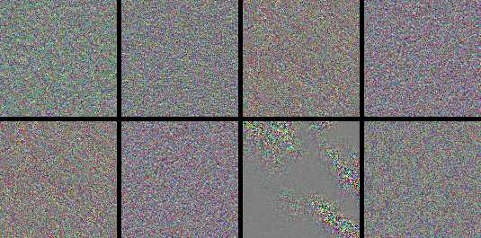

```
Now is processing the target layer conv2_1
Processing filter 0
Processing filter 1
Processing filter 2
Processing filter 3
Processing filter 4
Processing filter 5
Processing filter 6
Processing filter 7
```

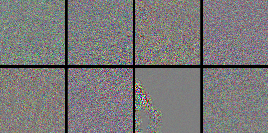

```
Now is processing the target layer conv3_1
Processing filter 0
Processing filter 1
Processing filter 2
Processing filter 3
Processing filter 4
Processing filter 5
Processing filter 6
Processing filter 7
```

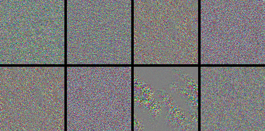

```
Now is processing the target layer conv4_1
Processing filter 0
Processing filter 1
Processing filter 2
Processing filter 3
Processing filter 4
Processing filter 5
Processing filter 6
Processing filter 7
```

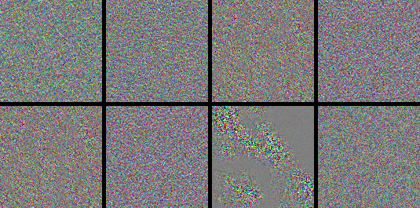

```
Now is processing the target layer conv5_1
Processing filter 0
Processing filter 1
Processing filter 2
Processing filter 3
Processing filter 4
Processing filter 5
Processing filter 6
Processing filter 7
```

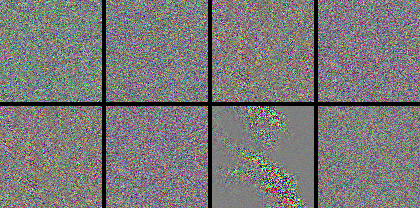

```python
def get_special_layer_filters(layer_name):
    layer = model_VGG16.get_layer(name=layer_name)
    feature_extractor = 0
    feature_extractor = keras.Model(inputs=model_VGG16.inputs, outputs=layer.output)
    #compute_show_filters()
    first_filter_number=8
    all_imgs = []
    for filter_index in range(first_filter_number):
        print("Processing filter %d" % (filter_index,))
        loss, img = visualize_filter(filter_index)
        all_imgs.append(img)

    # Build a black picture with enough space for
    # our 2 x 4 filters of size 128 x 128, with a 5px margin in between
    margin = 5
    n = 2
    m=4
    cropped_width = img_width - 25 * 2
    cropped_height = img_height - 25 * 2
    width = n * cropped_width + (n - 1) * margin
    height = m * cropped_height + (m - 1) * margin
    stitched_filters = np.zeros((width, height, 3))

    # Fill the picture with our saved filters
    for i in range(n):
        for j in range(m):
            img = all_imgs[i * n + j]
            stitched_filters[
                (cropped_width + margin) * i : (cropped_width + margin) * i + cropped_width,
                (cropped_height + margin) * j : (cropped_height + margin) * j
                + cropped_height,
                :,
            ] = img

    img_name = layer_name+"_stiched_filters.png"
    keras.preprocessing.image.save_img(img_name, stitched_filters)

    display(Image(img_name))
    return 0

#define the target layers
layer_names=['conv1_1','conv2_1','conv3_1','conv4_1','conv5_1']
for layer_name in layer_names:
    print("Now is processing the target layer "+layer_name)
    get_special_layer_filters(layer_name)
```

Task3: What do you notice in the different filters?

[output not shown]

Task4: What kind of information does each filter learn?

The filters in different layers of a convolutional neural network (CNN) can have different patterns and characteristics, which can help us understand how the CNN is processing the input data.

[output not shown]